# ボストン研修旅行 2018

参加者は、2年生から3年生の浅野ゼミ生をはじめ、浅野ゼミOB、早稲田大学の学生、白百合大学の学生、浅野先生の計11名です。滞在中のプランニングは参加者が個別に行い、少人数のグループに分かれて行動しました。短期間ではありますが、ボストン市内各所へ足を伸ばすことができ、大変密度の濃い研修でした。以下に主な活動内容を紹介させて頂きます。

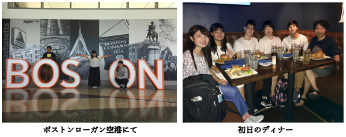

#### 8月28日

今回飛行機はJAL組とエアカナダ組に別れており、JAL組は10:55に飛行機に乗り、途中ダラス・フォートワース空港で乗り換え後15時にボストンに到着しました。エアカナダ組は17:30に飛行機に乗りカナダのモントリオールで乗り換え後18時30分頃到着しました。到着後、宿泊先であるウィンダム・ボストン・ビーコンヒル・ホテル周辺を散策し、夕食をとりました。

#### 8月29日

午前中にハーバード大学を見学しました。ハーバード大学はアメリカで最も古い大学として知られており、歴史ある大学を肌で感じることができました。ハーバード大学付近のお店でランチを食べました。夕方からはレッドソックスのホームであるフェンウェイ・パークにて、対マイアミ・マーリンズの試合を観戦しました。テレビで観る試合とは異なり、実際に観る試合はとても迫力があり興奮しました。

[figure not shown]

[figure not shown]

レッド・ソックス野球観戦

#### 8月30日

この日は、午前中にマサチューセッツ工科大学（M.I.T.）へ行きました。キャンパス内には個性的で印象的な建物が多く見られました。午後からは、フリーダム・トレイルというアメリカの歴史を学ぶ道を辿り市内の観光地と歴史的な名所を巡ることで、教科書に出てくるような著名な建物や船などを見ることができました。また、夕方にはパブリック・ライブラリーに行きました。館内は教会のような雰囲気で、時が経つのをわすれさせるような場所でした。

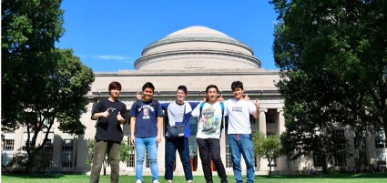

MITにて

[figure not shown]

#### 8月31日

この日は、早朝からパブリック・ガーデンに行きました。緑が沢山あり、日本ではあまり見られない野生のリスなども生息していました。公園内では時間がゆっくりと流れているように感じ、家族などで過ごしている人が沢山いたのが印象的でした。午後は、ボストン美術館に行きました 。絵画の他にも歴史的に価値のあるものが見られ、博物館のようで見ていて飽きませんでした。

#### 9月1日

この日は、APSAという愛称で親しまれているアメリカ政治学会にて浅野ゼミOBで4月から早稲田大学院（政治学研究科修士課程1年）に在籍している遠藤先輩の発表を聴くことが出来ました。論文にタイトルは Getting Electoral Systems to Count: Does Candidate’s Smile Matter in Japan? というもので、AIによる最新の顔認証技術を使って衆議院候補者ポスターの「笑顔度」を計測し「中選挙区制下では候補者の笑顔は集票に繋がったが、小選挙区制下ではその効果は無くなる」という内容の浅野先生との共著論文です。普段学会を聴講する機会は滅多にないので、とても貴重な体験をすることが出来ました。

[figure not shown]

APSA（アメリカ政治学会）で論文を発表中の遠藤先輩

#### 9月2日

この日は、水陸両用車のバスでボストン市内を周るダックツアーに参加しました。歩いて周る時と違った雰囲気を楽しむことが出来ました。ボストン滞在最終日ということもあり全員でsummer shackというシーフードのお店でディナーを食べました。ロブスターが絶品でした。

[figure not shown]

#### 9月3日

最終日もJAL組、エアカナダ組に別れそれぞれの便で帰国しました。

### 参加学生の感想

#### 白百合大学 人間総合学部 初等教育学科 1年 熊谷らん

私はこの研修で行ったボストンが初海外でした。ハーバード大学やボストン美術館など世界的に有名な場所に行けたこと、夢だった大リーグ観戦は一生の思い出になりました。初めてスターバックスで注文した時名前を聞かれて自分ではしっかり発音したつもりでしたが、全然違う名前で聞き取られてしまい発音の悪さを痛感しました。また、参加した政治学会では、ネイティブの先生方の発表の2割程度しか聞き取れませんでした。現地の人と普通に会話している先生、先輩方を見て自分もこんな風に話せるようになりたいと強く思いました。 今回の研修は得るものが本当に多かったです。コミュニケーション力、リスニング力をつけて、次は人に頼ってばかりではなく自分で自分の事は出来るようになってまた海外に行きたいです。

#### 政経学部 法律政治学科 2年 飯島千尋

私は、今回のボストンでの研修で様々な所に行きました。レッドソックスの観戦、ボストン美術館、パブリックガーデン…どこに行っても素敵な場所で、充実した時間を過ごすことができました。アメリカ人の方々は、とても寛容でおおらかで、その時初めて話したとは思えないくらい親しく話しかけてくれる人もいたためコミュニケーションを取れる機会も多く、1週間と言う短い時間でしたが、自分にとって成長できる場面が多くありました。また、今回の研修でアメリカの良さ、日本の良さを改めて実感できたため、とても有意義なものとなりました。一緒に行った人たちとも交流を深めることができたので良かったです。 またこの様な機会があったらぜひ参加したいです。

#### 早稲田大学 社会科学部 社会科学科 1年 上山敬之

私はボストンでハーバード大学やMIT、ボストン大学、ノースイースタン大学など、世界でトップレベルの大学を見学させていただき、自分の未熟さを痛感しました。また、アメリカ政治学会 (APSA) を見学させていただいた際、東京大学や早稲田大学の政治学の先生方を浅野先生に紹介していただきました。学部1年では本来行くことができないような場所へ連れて行ってくださった浅野先生、院生の中村さん、遠藤さんに感謝致します。今回の研修を通じて、自分の中に今まであった固定観念に疑問を抱くようになり、考え方が変わったような気がします。機会があれば、今度は自分ももう少し英語力と教養を身につけて渡米したいです。

#### 政経学部 法律政治学科 2年 堀井颯人

このボストン研修が私の人生初の海外渡航でした。ボストンでは、ハーバードやMIT、独立の歴史を辿るフリーダム・トレイル、MLB観戦など、記憶に残る体験が沢山できました。特にこの研修で1番記憶に残っているのは、ダラス空港で飛行機を乗り継ぎ、ボストンに向かう際のことです。明らかに海外旅行初心者の私達を心配した空港職員さんが私に”Follow me” と言って、搭乗口まで誘導してくれました。あの職員さんが誘導をしてくれていなかったら、私は広いダラス空港の中を永遠に彷徨う事になっていたかもしれません。 今回のボストン研修は、歴史や伝統を感じた研修であり、なによりも人の優しさを感じた研修となりました。 英語に関しては、ネイティブの英語を聞き取ることがとても大変でした。英語で会話をするチャンスが多くありましたが、会話を聞き取ることが難しく、上手くコミュニケーションを取れませんでした。耳をもっと鍛えて、また海外に行きたいと思いました。

#### 政経学部 法律政治学科 3年 滝瀬友優貴

ボストンの街並みは、レンガ造りの建物や落ち着いた雰囲気がよかったです。海外へ行くと、日本とは違った生活スタイルや文化があります。実際に海外へ行くことにより、日本では経験できないことをたくさん経験することができました。